# CHEM2003 Notes

# tutorial question and additional work

## chapter 1

section 1.1-1.3

self test 1.1

self test1.2

read 1.3d-1.3g

(see section 1.3 for explanation)

section 1.5-1.6

Self test 1.7-1.11

Exercises 1.9-1.15, 1.17-1.26, 1.28-1.31 (pp 32-33)

# section one general review

## Quantum numbers

### Introduction

Orbitals are a spacial distribution of electron density.All energy states of electrons within atoms are negative by convention, (as the are considered to be the minimum energy necessary to free that electron from its parent atom)

### principle quantum number

n

#### range

$n \in \mathbb{Z}^+| n \geq 1$

NOTE: although n is theoretically unbounded values greater than five have not yet been observed in reality.

#### details

Identifies a specific energy state Orbitals of the same quantum number form an part of the same electron shell

### Azimuthal quantum number (orbital angular momentum number)

l

#### encoding

values of l are given letters for identification

$\quad 0\rightarrow s$

$\quad 1\rightarrow p$

$\quad 2\rightarrow d$

$\quad 3\rightarrow f$

#### range

$l\in \mathbb{Z}\quad | \quad 0 \leq l \leq n-1\quad$

#### details

determines the size and shape of the sub shell/ determines the area around the nucleus which the electron may inhabit.

### Magnetic quantum number

#### range

$m_{l} \in \mathbb{Z} \quad | \quad -l \leq m_{l} \leq l\quad$

#### details

determines the three dimensional orientation of sub shell.

#### spacial orientations

P orbitals have three possible orientations

X,Y,Z

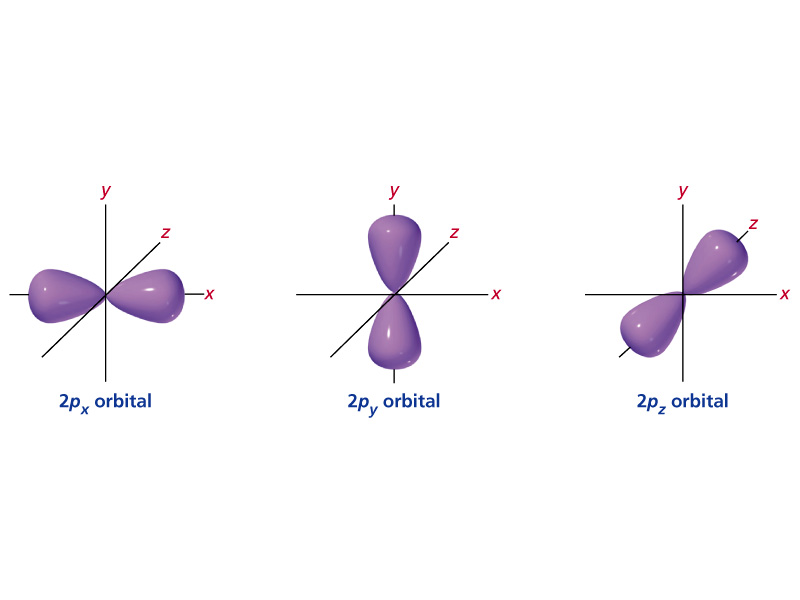

p orbital orientations

D orbitals have five possible orientations

$xy,xz,zy,z^{2},x^{2}-y^{2}$

[figure not shown]

d orbital orientations

F orbitals have seven possible orientations.

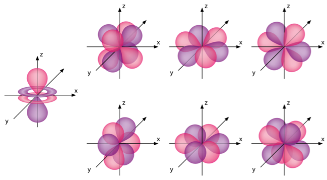

forbital orientations

### magnetic spin number $m_{s}$

#### range

$m_{s} \in \left( \frac{+1}{2},\quad\frac{-1}{2} \right)$

#### details

determines the direction of spin/ gyration of the electron in regard to the magnetic axis of the atom.

### representation diagrams

#### Standard representation

$nl^{s}$

Where:

```
  n= principle quantum number
  l= azimuthal number
  x= number of electrons within the l subshell.
```

#### Condensed representation

[noble gases] valence shell in standard representation

### Pauli Exclusion Principles.

no too electron within one atom can have the same set of quantum numbers

### Aufbau Priciple

electrons must always fill into the lowest energy levels available, this provides the sable ground state for of the atom.

### Hundu’s

degenerate orbitals must always be filled singly and by electrons with the same spin number before 2 electrons may fill the same orbital, and opposite spin numbers are permissible.

#### exchange with higher sub-shells

electrons are most lightly to be promoted into higher sub-shells when in doing so they can lead to completely singly filled, or completely double filled orbitals.

##### examples

Chromium

$[Ar]4s^{1}3d^{5}$

Copper

$[Ar]4s^{1}3d^{10}$

## Effective nuclear charge

effective nuclear charge is the charge exerted on a given electron within an atom by the (positively charged) nucleus of that atom

### shielding

shielding is the reduction of the full nuclear charge which and in isolation the nucleus would exert on an electron.

$Z_{eff} = Z - \sigma\quad$

where: $Z_{eff}$ = effective nuclear charge Z= nuclear charge $\sigma$ = shielding effect of other electrons.

this shielding effect is due to the present of other electrons within the atom which repel the electron in question reducing the net attractive force towards the nucleus which it feels.

(this reduction is often expressed as the reduction of $Z \quad to \quad Z_{eff}$ )

### penetration

the potential for the presence of an electron inside shells of other electrons. (?)

### Slater’s Rules

Estimated value for sigma

#### final electron is in a s or p orbital

- n-1 electrons contribute 0.85
- ns and np electrons contribute 0.35 to $\sigma\quad$
- n-2 or lower electrons contribute 1.0 to $\sigma\quad$

#### final electron is in a d or f orbital

- nf and nd electrons contribute 0.35 to $\sigma\quad$
- electrons in lower shells contribute 1. to $\sigma\quad$

### Trends

#### #1

The closer to the nuclear an electron is the smaller the difference between Z and $Z_{eff}$ will be.

#### #2

In terms of energy levels d>p>s

#### summary

Increases up and across the periodic table.

##### Exceptions

###### Hydrogen

the 2s and 2p orbitals have the same energy level.

###### potassium and calcium

4s energy level is lower than the 3p (?) (see section 1.3 for explanation)

## Periodic table

### History

first proposed in 1869 based on increased atomic weight.

families of elements with similar chemical properties (groups) with gaps in these families allowing for prediction.

### classifying elements.

#### Metallic character

##### metals

Good Conductors High lustre generally solid malleable ductile

##### metalloids

goo semiconductors some High lustre some low lustre generally solid some malleable some not malleable some ductile some not ductile

##### Non metals

not malleable low to no lustre not ductile poor conductors brittle gas

##### mixtures

###### metals and metals

alloys

###### non metals and metals

hard

###### non metals and non metals

volatile

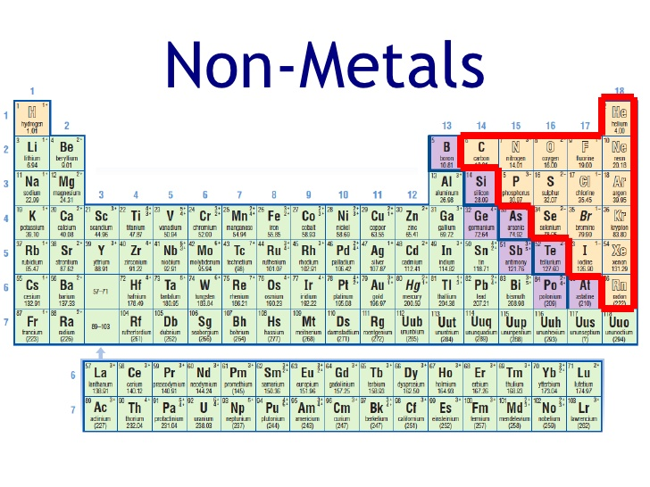

MetallicCharacter

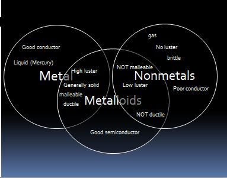

## Atomic properties

### Atomic and Ionic radii

radii measures are not very precise

#### Trends

increases down group and decreases across period.

this trend is offset between strontium and barium because $Z_{eff}$ is increased as there are more protons but few effectively shielding electrons. For orbitals are very bad at shielding (?)

##### Lanthanoid Contractions

D block elements don’t tend to expand or shrink properly

#### Covalent radius

half of the difference between centres of atoms in covalent bond (there is some overlap)

#### Ionic Radius

radius of atoms within ionic compounds, an average must be taken over many different ionic compounds as there is no reason to assume it would be half way between the atom centres.

##### mono atomic cations

monatomic cations are smaller than the parent atoms, as there is less shielding but equal nuclear charge so high effective nuclear charge.

##### monatomic anions

monoatomic anions are larger than their parent ions because they experience more shielding so lower effective nuclear charge

#### Metallic

half of the distance between atoms in a solid.

### Ionization Energy

Ionisation energy is the energy require to remove an electron from and atom (the standard is measure in gaseous conditions)

#### Trends

Ionisation energy increases up a group and across a period.

Correlated with atomic radii, but there are often exceptions depending on which sub-shell the electron in question is removed from.

### Electron Affinity

#### Electron enthalpy gain $\Delta_{eg}H^{\circ}\quad$

$\Delta_{eg}H^{\circ}\quad=-E_{a}-\frac{5}{2RT}$

$E_a$ is determined by the energy of the lowest unfilled or half filled orbital.

$E_a$ can be high if the electron added can experience a strong effective nuclear charge.

### ELectronegativity $\chi\quad$

the power of an element to attract electrons towards itself when it is part of a compound.

#### Mulliken Electronegativity ($\chi_{M}\quad$)

Atoms with higher ionisation energies and electron affinities are more likely to gain electrons

Atoms with low ionisation energies and low electron affinities are more likely to lose electrons.

$\chi_{M}=(I+E_{a})$

#### Pauling Electronegativity

Pauling energetics is related to the energetic of bond formation

If $BE(A-B)>\frac{1}{2}(BE(A-A)+BE(B-B))$ then the covalent bond contains an ionic contribution

Equation (?)

#### Trends

related to atomic size and electron configuration

increases up group and across period.

### Polarizability

the ability of an atom to be distorted by an electric field

#### polarizable

large highly charged anions are highly polarisable.

Cations that do not have noble gas configuration are easily polarisable.

#### polarizing or polarizing ability.

small highly charge cations have high polarisability.

## Electron structures

### Lewis structures.

A covalent bond is formed when two neighbouring atoms share an electron pair.

#### The Octet Rule

Each atom share electrons with neighbouring atoms to achieve a total on 8 valence electrons.

(there are many exceptions to this rule.)

#### Procedure.

1. Count the total number of valence electrons from all atoms involved, (add/subtract for ions as necessary.)
2. Atom which is least electronegative (cannot be hydrogen )
3. Make octets around outer atoms.
4. Share as many outer electron pairs with central atom to make covalent bonds as necessary to create an octet around central atom.
5. determine which structure has the lowest overall formal charge, and the most electro-negative formal charge on the most negative atom.

#### Exceptions

##### Expanded Octets

the presence of available d orbitals within acceptable energy ranges allows for more than 8 valence electrons around the central atom. this confirmation is known as hypervalent.

#### Formal charge.

The number of electrons assigned to each atom. is The sum of its unshared valence electrons plus 1 electron per covalent bond it forms

the formal charge of an atom in a compound is the number of electrons normally present in its valence shell minus the number of electron assigned to it in its given lewis structure.

NOTE: Sometimes lowest formal charge violates octet rule for central atom

#### Resonance

when two, or more lewis structure with identical formal charges and atomic conformation indicates a resonance structure. this compound exist in a state between the two formal structures, with intermediate bond lengths and energy levels. As bonding is distributed across the whole molecule so the energy of the resonance hybrid is lower than any single structure

### Predicting Shapes

#### Bonding vs Non Bonding pairs.

non bonding electrons have a greater repellent force, hence their position equatorial/ axial must place them as far away from each other as possible, and as far away from as many other electrons pairs as possible.

Bonding pair are also physically smaller than non bonding pairs.

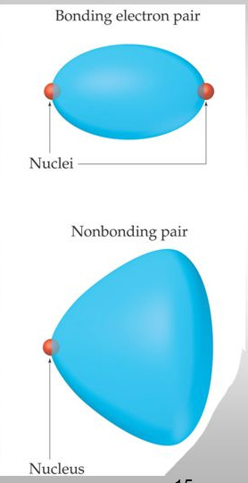

Bonding vs Non Bonding Pairs

#### Bond Angles

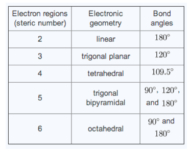

Bond Angles

##### Exceptions

1. Lone pairs distort bond angles by about 2.5 degrees
2. multiple bonds also distort bond angles.

[output not shown]

This table is fucked, it will not display for shit*

[figure not shown]

ElectronDomainGeometry

# Steriochemistry

Spectroscopy is a set of techniques in which the rtespose of molecules ot the input of energy is measured, that is , eletromagnetic radiation is applied to compounds and their response is then measured.

## Electromagnetic waves.

### Wave nature.

Electromagnetic waves consist of and electric and magnetic field which oscillate orthogonally to each other, and orthogonally to the direction of propagation of the wave.

#### Wavelength

Wavelength is donated by $\lambda$ and measured in meters (sometimes nm are used such as when UV or visible light is being discussed).

#### Velocity

Speed is donated by $c$. The speed of light in a vacuum ($c_0$) is constant ($3.00 \cdot 10^{8}m\cdot s^{-1}$), normally the speed of light is given in $m\cdot s^{-1}$

#### Frequency

frequency is donated by $\nu$ (?) and is measured in Hertz (Hz) that is $s^{-1}$

#### Wavenumber

Wavenumber is donated by $\overline{\nu}$, and is the reciprocal of wavelength. It is measured in $cm^{-1}$ and used most commonly in IR spectra.

### Particle nature.

Photons are particles of light. There particles posses a distinct quantised energy given by $E=h\nu$

### Gamma rays.

The energy of photons is too high breaking up molecules changing their structure.

### X rays.

The energy of photons is too high breaking up molecules changing their structure.

### Ultra violet and visible light.

Affect the valence electrons of molecules exciting them to a higher state.

### Microwaves.

Affect bond bending.

#### radiowaves.

Affects the erergy levels associated with the magnetic field which is associated with electron, or protons within the nucleus.

## Obtaining spectra.

Radiation of known wavelength is passed through the sample and the decrease in intensity of the radiation is observed. The absorbance of the sample is them calculated. The process is repeated over a range of wavelengths to give a graph of intensity or absorbance against time.

### Beer-lamert Law.

The Beer lambert law given by the expression. $A=cb\epsilon$

NOTE: The energy of the regions of EM of interest have energies of $1-^{-20}-10^{-28}$, i.e very small.

## Absorbance spectra

Absorbance results when molecules in a low energy state are excited to a higher energy state by the absorption of a photon of energy. The change in energy which occurs is donated as $\Delta E$. (This form of absorption is that which is typically used for IR, UV, visible and NMR spectra)

## Double bond equivalents.

The advantage of double bond equivalents is that they can be used to at least propose several possible structure for a compound.

# Organic chemistry

## Course Background.

### Lecturer

Dr Kennedy Ngwira, C407, Dr Amond Rouseou. C503.

### Isomers.

#### Structural isomers.

Structural isomers are compounds with the same atomic composition and molecular formula, but different atomic arrangments.

#### Stereo isomers.

##### Conformational

Conformational isomers are characterised by free rotation around a particular (C-C) bond, hence at least one single bond is required in the structure. Due to the free rotation the different isomeric forms can be rapidly interconverted.

###### Eclipsed.

In eclipsed conformation, when view along the axis of the bond the groups attached to the atoms of the bond lie dirrectly behind eachother.

###### Cyclic compounds

cyclic compounds can also form coformational isomers which take on the boat, or chair conformation.

##### Geometric

Geometric isomers require a rigidn unit such as a double bond ($\pi$ bond), or a cyclic compound which prevents free rotation.

###### Cis trans.

In cis trans nomeclature the cis conformation has groups of higher proprity on the same size, the trans has them on opposite sides. ( higher priority is assigned to the group which is connected by the atom with the higher atomic number, if atomic number is equal then mass number is used))

###### Carn-Ingold Prelog (E,Z)

The Carn-Ingold Prelog system (C.I.P rules) are used to assign priorities. higher priority is assigned to the group which is connected by the atom with the higher atomic number, if atomic number is equal then mass number is used. If the first atom is identical then the atomic weight of the next atom in the chain is compared. multiple bonds are considered as an equvalent number of single bonds to the given atom.

If the higher priorety groups are on the same side then the molecule is in Z conformation (where Z stands for Zussamen/together). If the higher priorety groups are on opposite sides then the molecule is th the E, Enitgen conformation.

##### Enantiomers (Optical isomers)

Moeluces whise mirror images are not superimposed.

###### Requirements.

$sp^3$ hybridised carbon, with four differernt substituents ()i.e a steric carbon.

The sp^3 hybridised carbon must have four different groups attatched to it.(For example alanine). The resulting system is asymetrical, and will have a non-superimposable missor image.

NOTE: the central carbon may be refferd to as a steriocarbon, a steriogentic centre or a hydrocarbon.

###### Properties.

Inantomers have practically identical(almost indistinguishable) physical and chemical properties are therfore very hard to separate. Furthermore Racemic mixture are hard to detect. This is porblematic as often one inatomer may be a powerful medical drug and the other may be seriously toxic.

###### Polarised light

inantomers will rotate plane polerised light differently. They will rotate the plane of polerised light to the same extend to one will rotate to the right (+, dextrorotatory) the other will rotate to the plane to the left (-, levorotatory)(equal but opposite).

###### Optical activity

optically active substances will rotate plae polerised light. A Racemic mixture is opticcally inactive.

NOTE: A Racemic mixture is a mixture containing an equal concnetration of both enantomers.

### Nomecalture.

The + or - is prefixed to the compound name. The problem is that the + and - configuration are determined experimentally and cannot be determined dirrectly from the steriochemistry around the steriocenter.

A new system was developed to overcome this problem, the process for which is as follows.

1. Priorities are assigned to each group using the C.I.P rules. (note 1 is used for highest priorety, on to 2 etc).
2. The molecule is orientated with the lowest priority group at the back.
3. If the remaining 3 substituents run from highest to lowest clockwise then the isomer is on R configuration.
4. If they are arranged anticlockwise the entantomer is S.

Example: Br>Cl>C>H

1. Clockwise, R
2. anticlockwise S.

NOTE: Flipping any two groups will result in the opposite entantomer. swapping inverts the configuration from R to S.

## Diasteriomers. Occur if more than one steriocentre is present. Diastereomers are not mirror images.

(Copy flag diagram) For a diassteriogentic centres there are a maximum of $2^n$ stereoisomers. Half of these will be enantomers of the other half. all of the other relationships are diateriomers.